# Airbnb_NYC_2019_Final-update2

# Question 2: Which locations generate the most revenue? Which locations have the most potential for future growth?

### Which Boroughs generate the most revenue?

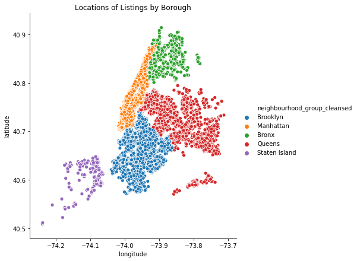

```python
sns.relplot(x='longitude', y='latitude', hue='neighbourhood_group_cleansed',
            data=listings_explore, height=6, aspect=1)
plt.title('Locations of Listings by Borough')
plt.show()
```

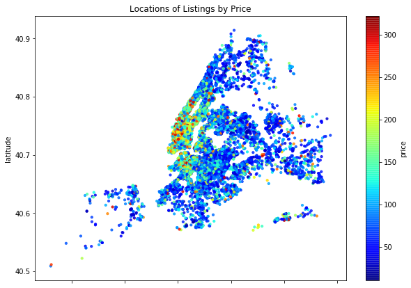

```python
listings_explore.plot(kind='scatter', x="longitude", y="latitude", alpha=0.8,
                            figsize=(10,7), c='price', cmap=plt.get_cmap("jet"),
                            colorbar=True, s=10)
plt.title('Locations of Listings by Price')
plt.show()
```

Manhattan and northern Brooklyn have significantly higher prices than other boroughs (the lowest Manhattan prices are in the far Upper West Side nearing the Bronx). Prices also seem to rise near bodies of water.

Note that business districts like Mid-City and Wall Street are not only tourist hubs but can also be for Airbnb business trips at these higher price-ranges.

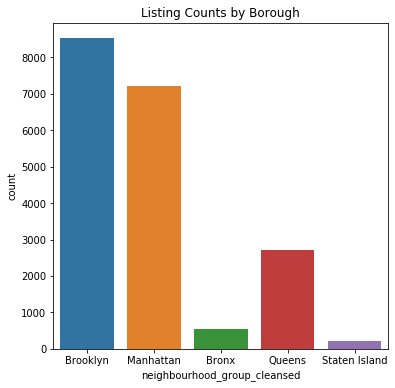

```python
plt.figure(figsize=(6,6))
sns.countplot(listings_explore.neighbourhood_group_cleansed)
plt.title('Listing Counts by Borough')
plt.show()
```

Brooklyn is the largest borough by listings with 8527 listings, followed by Manhattan with 7212, Queens has 2725, Staten Island has 217.

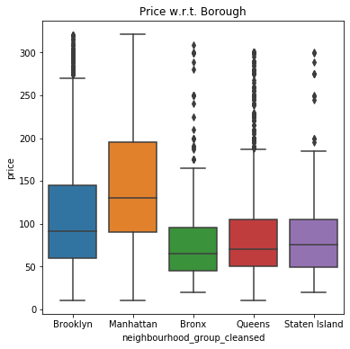

```python
plt.figure(figsize=(6,6))
sns.boxplot(x='neighbourhood_group_cleansed', y='price',
            data=listings_explore)
plt.title('Price w.r.t. Borough')
plt.show()
```

Manhattan commands the highest median prices at 130, with Brooklyn in 2nd at 91 (Brooklyn's upper range likely comes from northern Brooklyn. Brooklyn is large and the outskirts are not as tourist-centered as Manhattan). Bronx, Queens, and Staten Island have the lowest median prices at 65, 70, and 75 respectively.

### Which Borough's room types generate the most revenue?

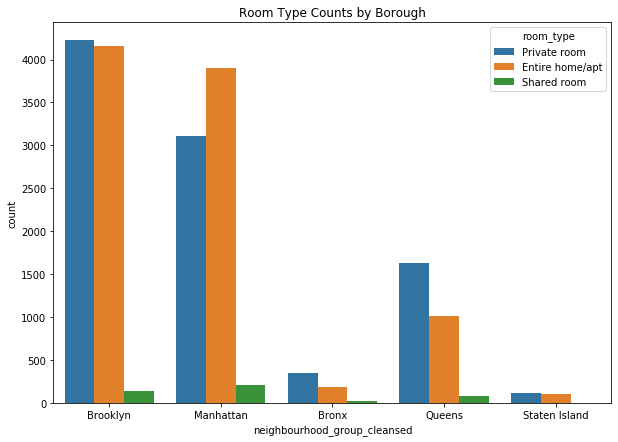

```python
plt.figure(figsize=(10,7))
sns.countplot(listings_explore.neighbourhood_group_cleansed, hue=listings_explore.room_type)
plt.title('Room Type Counts by Borough')
plt.show()
```

Private rooms and entire homes are by far the most common room types, at about equal frequencies. Shared rooms have very low counts in comparison.

Brooklyn has a higher ratio of private rooms, while Manhattan has a higher ratio of entire homes/apartments. Just based on local knowledge, this is likely because more Manhattan hosts have a place to themselves, while Brooklyn hosts tend to have more roommates. This would be one reason that Manhattan's median prices are higher than Brooklyn's, along with property values in general being higher in Manhattan, since entire homes/apartments rent for higher prices than private rooms. Queens has more private rooms than entire homes/apartments.

### Which neighborhoods generate the most revenue?

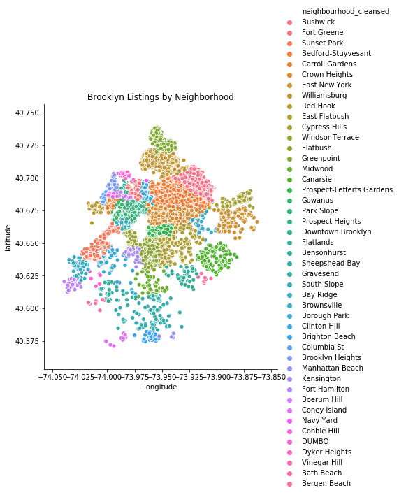

```python
sns.relplot(x='longitude', y='latitude', hue='neighbourhood_cleansed',
            data=listings_explore[listings_explore.neighbourhood_group_cleansed=='Brooklyn'], height=6, aspect=1)#, legend=False)
plt.title('Brooklyn Listings by Neighborhood')
plt.show()
```

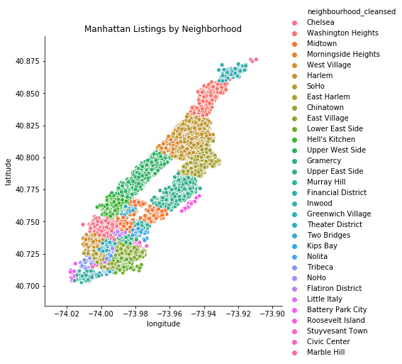

```python
sns.relplot(x='longitude', y='latitude', hue='neighbourhood_cleansed',
            data=listings_explore[listings_explore.neighbourhood_group_cleansed=='Manhattan'], height=6, aspect=1)#, legend=False)
plt.title('Manhattan Listings by Neighborhood')
plt.show()
```

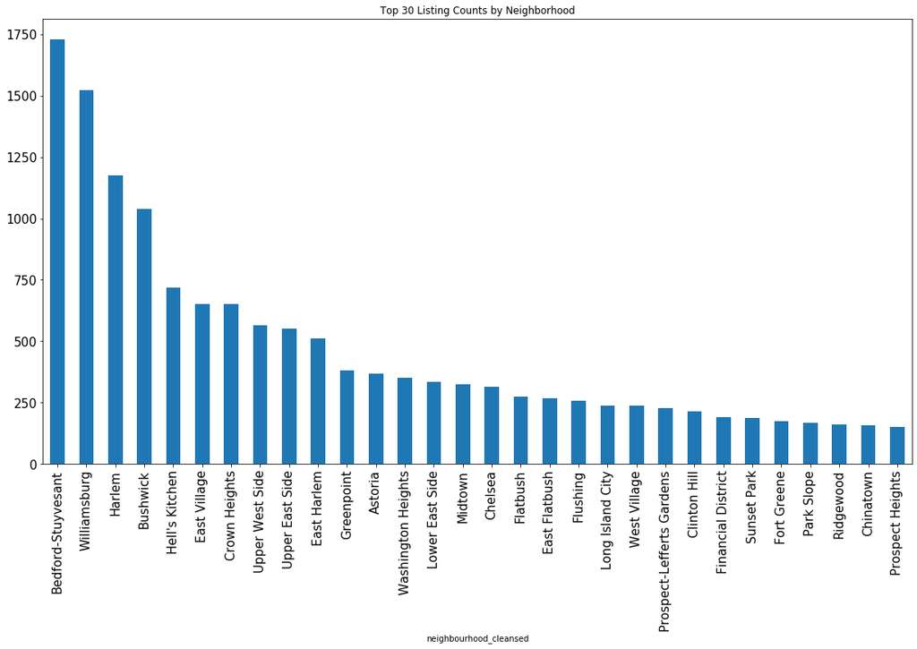

```python
plt.figure(figsize=(19,10))
listings_explore.groupby('neighbourhood_cleansed').count().price.sort_values(ascending=False)[:30].plot(kind='bar')
plt.title('Top 30 Listing Counts by Neighborhood')
plt.xticks(fontsize=15)
plt.yticks(fontsize=15)
plt.show()
```

The top 30 neighborhoods by listing count come primarily from Brooklyn and Manhattan, ranging from about 200 listings to 1750 listings. The top 4 neighborhoods by listing count are Bedford-Stuyvesant, Williamsburg, Harlem, and Bushwick.

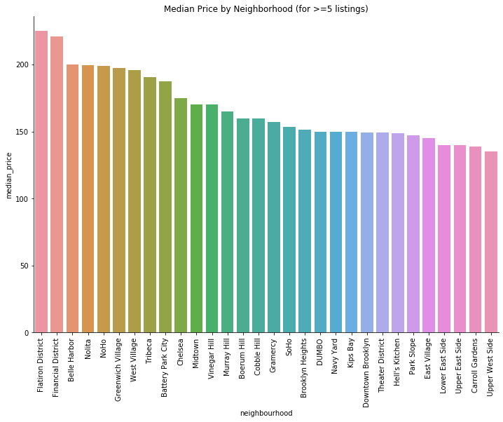

```python
# Create dataframe of neighborhoods and their median prices (for >=5 listings)

neighbourhoods_medians = []
neighbourhoods_names = []

for neighbourhood in listings_explore.neighbourhood_cleansed.unique():
    #print('{} Prices:\n'.format(neighbourhood))
    if len(listings_explore[listings_explore.neighbourhood_cleansed == neighbourhood]) >= 5:
        neighbourhoods_medians.append(listings_explore[listings_explore.neighbourhood_cleansed == neighbourhood].price.median())
        neighbourhoods_names.append(str(neighbourhood))

nbh_medians = pd.DataFrame({'neighbourhood': neighbourhoods_names, 'median_price': neighbourhoods_medians})
nbh_medians.sort_values(by=['median_price'], ascending=False, inplace=True)

# Top 10 and bottom 10 median prices (for neighborhoods with >=5 total listings)
#sns.set(font_scale=1.5, )
fig = sns.catplot(x='neighbourhood', y='median_price', data=nbh_medians.iloc[pd.np.r_[0:30]],#, -19:-1, -1]],
                  kind='bar', height=7, aspect=1.5)
fig.set_xticklabels(rotation=90)
plt.title('Median Price by Neighborhood (for >=5 listings)')
plt.show()
```

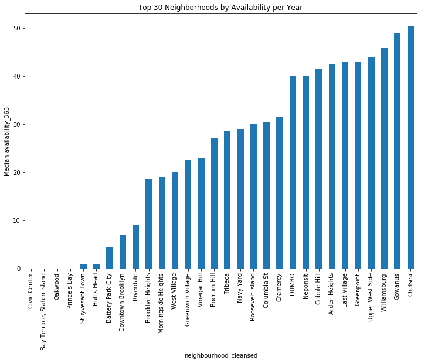

```python
listings_explore.groupby(['neighbourhood_cleansed']).median().availability_365.sort_values(ascending=True)[:30].plot(kind='bar', figsize=(12,8))
plt.title('Top 30 Neighborhoods by Availability per Year')
plt.ylabel('Median availability_365')
plt.show()
```

Many of the top 30 highest median priced listings are also in the top 30 lowest availabilities per year, and as with median price, most of these listings with low availabilities are in Manhattan and Brooklyn.

Namely, the neighborhoods generating the most revenue have the highest median price, lowest median availabilities, and high listings counts:

Brooklyn: Downtown Brooklyn, Brooklyn Heights, DUMBO, Bedford-Stuyvesant, Bushwick, Williamsburg.

Manhattan: East Village, West Village, Greenwich Village, Tribeca, Chelsea, Harlem, Upper West Side.

Queens: Astoria, Flushing, Long Island City.

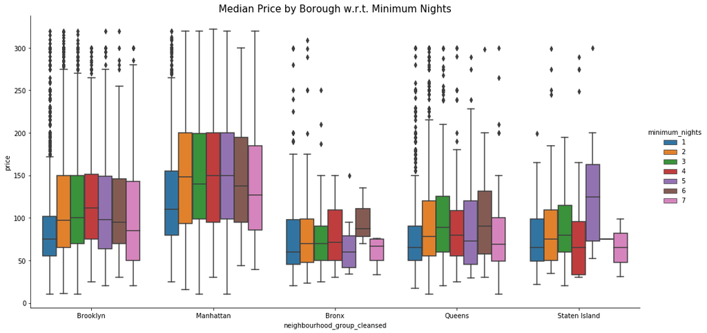

```python
sns.catplot(x='neighbourhood_group_cleansed', y='price',
            data=listings_explore, kind='box',
            hue='minimum_nights', height=7, aspect=2)
plt.title('Median Price by Borough w.r.t. Minimum Nights', fontsize=15)
plt.show()
```

For Brooklyn and Manhattan, the highest median prices are for minimum nights of 2-6.

### Importing Census Data

In order to draw further insights on location, we will pool NYC borough data from census.gov (2017): (https://www.census.gov/quickfacts/fact/table/newyorkcountymanhattanboroughnewyork,bronxcountybronxboroughnewyork,queenscountyqueensboroughnewyork,kingscountybrooklynboroughnewyork,richmondcountystatenislandboroughnewyork,newyorkcitynewyork#) (https://www.baruch.cuny.edu/nycdata/income-taxes/hhold_income-numbers.htm)

### How do demographics affect revenue by borough?

```python
nyc_stats
```

|  | Borough | households | median_household_income | total_listings | households_per_listing | median_listing_price | total_revenue |
| --- | --- | --- | --- | --- | --- | --- | --- |
| Brooklyn | Brooklyn | 944650 | 52782 | 8525 | 111 | 91 | 918424 |
| Manhattan | Manhattan | 758345 | 79781 | 7209 | 105 | 130 | 1040761 |
| Bronx | Bronx | 495356 | 36593 | 551 | 899 | 65 | 42506 |
| Queens | Queens | 777904 | 62008 | 2724 | 286 | 70 | 240447 |
| Staten_Island | Staten Island | 166150 | 76244 | 217 | 766 | 75 | 18769 |

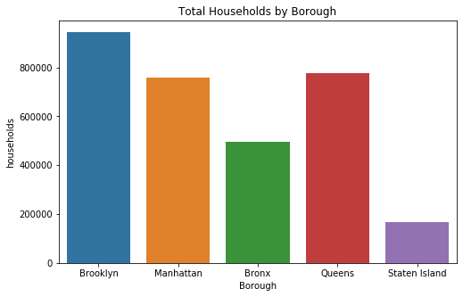

```python
plt.figure(figsize=(8,5))
sns.barplot(x='Borough', y='households', data=nyc_stats)
plt.title('Total Households by Borough')
plt.show()
```

```python
nyc_stats['households']
```

```
Brooklyn         944650
Manhattan        758345
Bronx            495356
Queens           777904
Staten_Island    166150
Name: households, dtype: int64
```

Brooklyn has the most households by borough with 944,000. Interestingly, Queens has the 2nd-most households with 778,000, followed closely by Manhattan with 758,000. Queens is an area for growth since it has a semi-strong presence on Airbnb, but plenty of room to expand. However, because it is more suburban, many potential listings are likely family homes that are not very often available for rent--and tourists are not as keen to rent in suburban areas far from the city center.

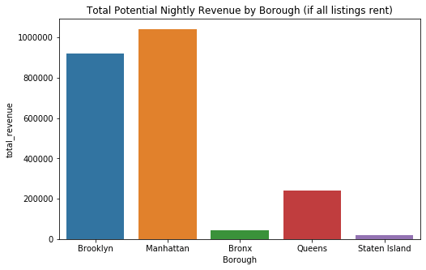

```python
plt.figure(figsize=(8,5))
sns.barplot(x='Borough', y='total_revenue', data=nyc_stats)
plt.title('Total Potential Nightly Revenue by Borough (if all listings rent)')
plt.show()
```

Manhattan has the highest potential revenues based on our current listings data, followed closely by Brooklyn. Despite Brooklyn's higher listings count, Manhattan's higher prices has propelled it to the top.

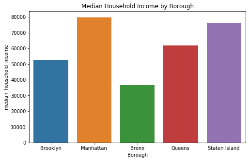

```python
plt.figure(figsize=(8,5))
sns.barplot(x='Borough', y='median_household_income', data=nyc_stats)
plt.title('Median Household Income by Borough')
plt.show()
```

This chart's analysis is below, combined with household income by borough analysis.

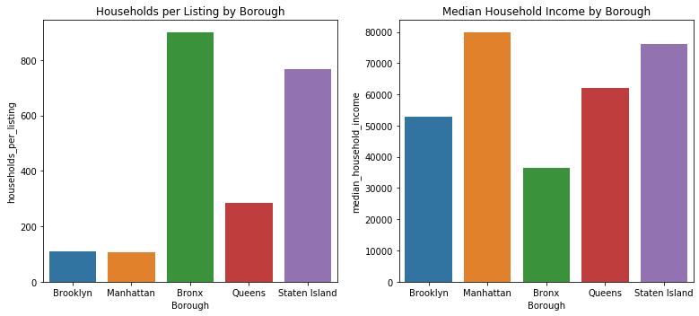

```python
fig, ax = plt.subplots(1,2, figsize=(11,5))
sns.barplot(x='Borough', y='households_per_listing', data=nyc_stats, ax=ax[0])
ax[0].set_title('Households per Listing by Borough')
sns.barplot(x='Borough', y='median_household_income', data=nyc_stats, ax=ax[1])
ax[1].set_title('Median Household Income by Borough')
plt.tight_layout()
plt.show()
```

Bronx likely has such a high ratio because of its lower median incomes deterring potential guests from the area. Staten Island's median income at 76,000 almost compares to that of Manhattan at 79,000. For how many listings Brooklyn has, it has the 2nd lowest median income at 53,000. Queens comes in 3rd at 62,000.

Brooklyn's lower median income but higher listings ratios is likely explained by its neighborhoods. Northern Brooklyn's prices almost compare to that of Manhattan, while the rest are much lower, and are much further from the city center.

# Question 3: Do listings with higher ratings generate more revenue?

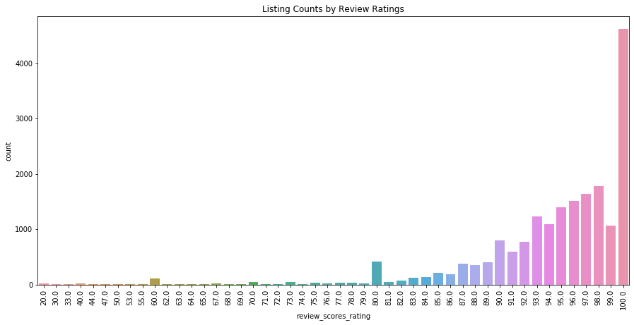

```python
plt.figure(figsize=(15,7))
ax = sns.countplot(listings_explore.review_scores_rating.round(0))
ax.set_xticklabels(ax.get_xticklabels(), rotation=90)
plt.title('Listing Counts by Review Ratings')
plt.show()
```

The listings with higher review ratings, namely in the 80s, 90s, and 100, are by far the most common listings by count.

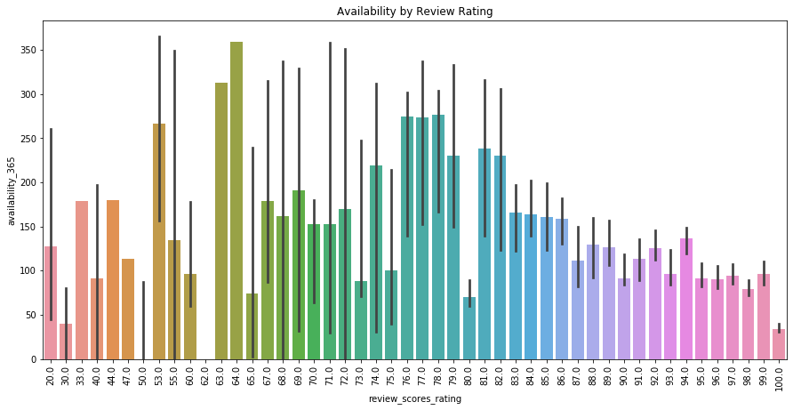

```python
plt.figure(figsize=(15,7))
ax = sns.barplot(x=listings_explore.review_scores_rating.round(0), y=listings_explore.availability_365, estimator=median)
ax.set_xticklabels(ax.get_xticklabels(), rotation=90)
plt.title('Availability by Review Rating')
plt.show()
```

Listings with higher ratings tend to have lower median availability per year. If we can determine that listings with higher ratings also tend to have higher median prices, we can conclude that listings with higher ratings generate more total revenue.

Nearly 90% of listings have review score ratings of 90 or above.

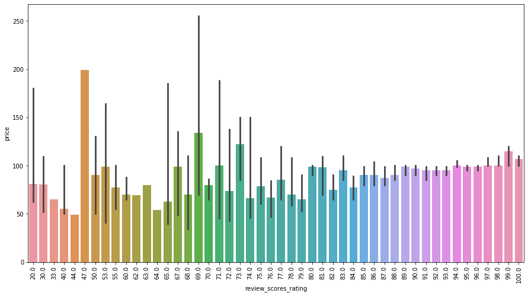

```python
plt.figure(figsize=(15,8))
ax = sns.barplot(x='review_scores_rating', y='price',# hue='neighbourhood_group_cleansed',
                 data=listings_explore, estimator=median)
ax.set_xticklabels(ax.get_xticklabels(), rotation=90)
plt.show()
```

Prices are slightly higher and more stable for listings rated above 90, but once scores surpass 90, prices remain rather uniform from 90-100 (increasing very slightly as ratings increase). Because almost 90% of listings are rated at 90% or above, this means that listings with higher ratings generate more revenue due to both their higher frequency and higher median prices.

Listings rated below 90% are much more rare in frequency, and median prices vary much more, but are generally lower than the listings rated 91-100.

### Do superhosts have higher ratings than non-superhosts?

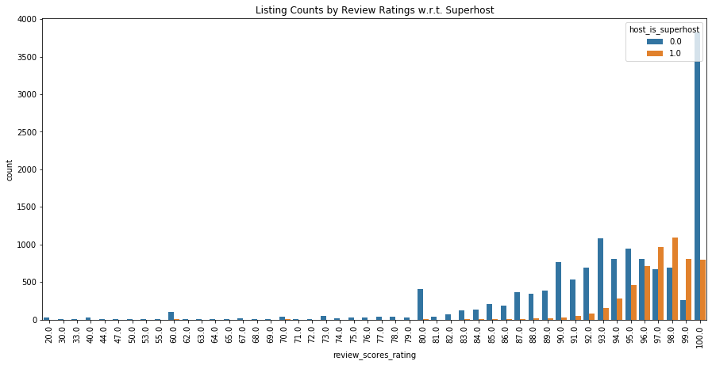

```python
plt.figure(figsize=(15,7))
ax = sns.countplot(listings_explore.review_scores_rating.round(0), hue=listings_explore.host_is_superhost)
ax.set_xticklabels(ax.get_xticklabels(), rotation=90)
plt.title('Listing Counts by Review Ratings w.r.t. Superhost')
plt.show()
```

As review score ratings increase, the ratio of superhosts to non-superhosts increases as well. Nearly all superhosts have above 90% review score ratings.

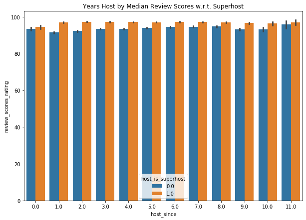

```python
plt.figure(figsize=(10,7))
sns.barplot(x='host_since', y='review_scores_rating', hue='host_is_superhost', data=listings_explore)
plt.title('Years Host by Median Review Scores w.r.t. Superhost')
plt.show()
```

Superhosts do tend to have slightly higher ratings, but as seen in previous analysis, their benefit comes not from higher median prices but from lower vacancy. Therefore it is possible that guests are not willing to pay more for a superhost's listing, but will choose it over a similarly priced listing by a non-superhost. This choice could either be due to guests preferring superhost status, or the superhost's higher reviews, and is likely a combination of both.

# Multi-Variate Analysis Conclusions

With our new insights, we can now review the questions we set out to answer with this analysis.

**1. Which hosts generate the most revenue?**

Hosts renting from years 1-7 are the largest segments of hosts, with the lowest levels of availability. They generate the most revenue due to their high numbers and low availability. Superhosts generate more revenue than standard hosts due to their even lower availability.

The highest revenue-generating host segment are hosts with high listings counts who have been renting for 1-7 years renting room-type entire house/apartment. A smaller but even more profitable segment are these same hosts that are also superhosts.

**2. Which locations generate the most revenue?**

By borough, Manhattan followed by Brooklyn generate the most revenue with respect to borough due to their high listing counts and low availabilities. More specifically for both boroughs, entire homes/apartments generate the most revenue, followed closely by private rooms. Brooklyn has more listings but Manhattan commands higher prices due to both location and a higher ratio of entire homes/apartments.

West Queens and South Bronx show the most potential for growth due to their high ratios of households to listings, along with their proximity to the city center as population increases. As South Bronx continues gentrifying, median incomes will rise, potentially giving way to new listings with higher prices as tourists become more comfortable with the area. West Queens will continue urbanizing from its suburban roots as population from the city center expands, also giving way to new listings as the borough begins to let go of its suburban roots. Staten Island is our lowest earner, yet there is potential for vacation homes, rather than urban tourist renting, as median incomes are quite high in the borough.

Not surprisingly, most neighborhoods generating the most revenue come from Manhattan and Brooklyn, having the highest frequencies, highest median prices, and lowest availabilities. The highest revenue-generating neighborhoods consist of:

Brooklyn: Downtown Brooklyn, Brooklyn Heights, DUMBO, Bedford-Stuyvesant, Bushwick, Williamsburg.

Manhattan: East Village, West Village, Greenwich Village, Tribeca, Chelsea, Harlem, Upper West Side.

Queens: Astoria, Flushing, Long Island City.

**3. Do listings with higher ratings generate more revenue?**

Listings rated at 90 and above generate more revenue due to higher listing counts, higher median prices, and lower availabilities. Superhosts tend to have slightly higher ratings than standard hosts, and as seen above they have lower availability rates, so based on ratings, Superhosts with ratings above 90 generate the most revenue, followed by non-superhost hosts with ratings above 90.

## Actionable Insights

Consolidating our analysis, our highest revenue-generating listings come from entire homes/apartments and private room listings rated at 90 or above, located primarily in boroughs Brooklyn and Manhattan, along with a few neighborhoods in Queens. More specifically, the highest-revenue neighborhoods are:

Brooklyn: Downtown Brooklyn, Brooklyn Heights, DUMBO, Bedford-Stuyvesant, Bushwick, Williamsburg.

Manhattan: East Village, West Village, Greenwich Village, Tribeca, Chelsea, Harlem, Upper West Side.

Queens: Astoria, Flushing, Long Island City.

The highest revenue-generating hosts of these listings have been hosts from 1-7 years, with superhosts generating slightly more revenue than non-superhosts. Hosts with high listings counts generate even higher listings, naturally, since they are renting multiple listings.

Airbnb's host-marketing efforts should aim towards this demographic of host, in the highest revenue-generating neighborhoods of Brooklyn, Manhattan, and Queens. Marketing promotions in order to keep these hosts loyal would keep these hosts generating the highest revenues. Marketing areas for potential growth campaigns include neighborhoods in West Queens expanding into more urban areas from their suburban roots, and nighborhoods in South Bronx that are gentrifying as median income levels rise from the city's steady population growth.

Guest-marketing efforts should focus in on guests interested in traveling to these areas, using further data from Airbnb customer data or third-party consumer data. With more data, guests can also be segmented by tourist vs. business-travelers in order to aim effectively specialized marketing campaigns at high revenue-generating guests looking to stay in these areas.

# Preparing Training Set for Machine Learning Models

Now that we have finished our analysis, we will begin preparing our training data for our machine learning models. First, we will remove the features with high collinearity from our correlation heatmaps to prepare the DataFrame for our machine learning models.

```python
listings_explore.drop(columns=corr_drop, inplace=True)
dropped_cols.extend(corr_drop)

# remove items from attribute lists
for attrib in corr_drop:
    try:
        num_attribs.remove(attrib)
    except ValueError:
        pass
for attrib in corr_drop:
    try:
        disc_attribs.remove(attrib)
    except ValueError:
        pass
for attrib in corr_drop:
    try:
        cat_attribs.remove(attrib)
    except ValueError:
        pass
for attrib in corr_drop:
    try:
        amen_attribs.remove(attrib)
    except ValueError:
        pass
```

We will now create a function to clean any listings dataframe based on the preprocessing performed above. This way, any new data can be cleansed through this function in the future, including the test set.

```python
# Pipeline to clean dataframe
def clean_listings(df):
    '''
    Cleans listings dataframe to prepare for ML models.

    Args:
    df -- uncleaned listings dataframe

    Returns:
    clean_df -- cleaned listings dataframe'''

    # 1. Price (string mod)

    # Remove string characters, convert to float
    df['price'] = df['price'].astype('str')
    df['price'] = df['price'].str.replace('.00', '', regex=False)
    df['price'] = df['price'].str.replace('$', '', regex=False)
    df['price'] = df['price'].str.replace(',', '', regex=False)
    df['price'] = df['price'].astype('float64')

    # 2. number_of_reviews_ltm (cut)

    # Only include number_of_reviews_ltm > 0
    df = df[df.number_of_reviews_ltm > 0]

    # 3. host_since (string mod)

    # Convert to how many years host
    df['host_since'] = 2019 - df['host_since'].str[:4].astype('float64')

    # 4. cleaning_fee (string mod)

    # Remove string characters, convert to float
    df['cleaning_fee'] = df.cleaning_fee.str.replace('$', '', regex=False)
    df['cleaning_fee'] = df.cleaning_fee.str.replace('.00', '', regex=False)
    df['cleaning_fee'] = df.cleaning_fee.str.replace(',', '', regex=False)
    df['cleaning_fee'] = df.cleaning_fee.astype('float64')

    # 5. extra_people (string mod)

    # Remove string characters, convert to float
    df['extra_people'] = df.extra_people.str.replace('$', '', regex=False)
    df['extra_people'] = df.extra_people.str.replace('.00', '', regex=False)
    df['extra_people'] = df.extra_people.str.replace(',', '', regex=False)
    df['extra_people'] = df.extra_people.astype('float64')

    # 6. minimum_nights (cut)

    # only include minimum_nights <= 7
    df = df[df.minimum_nights <= 7].copy(deep=True)

    # 7. maximum_nights (cap)

    # Cap maximum_nights at 1125
    df['maximum_nights'].values[df.maximum_nights > 180] = 180

    # 8. host_is_superhost (convert to 1/0)

    # Convert t/f to 1/0
    df['host_is_superhost'] = convert_tf(df, 'host_is_superhost')

    # 9. property_type (filter)

    # Filter specific property types
    df = df[
                           (df.property_type == 'Apartment') |
                           (df.property_type == 'House') |
                           (df.property_type == 'Condominium') |
                           (df.property_type == 'Townhouse') |
                           (df.property_type == 'Guest suite') |
                           (df.property_type == 'Guesthouse') |
                           (df.property_type == 'Loft') |
                           (df.property_type == 'Serviced apartment') |
                           (df.property_type == 'Tiny house') |
                           (df.property_type == 'Earth house') |
                           (df.property_type == 'Villa') |
                           (df.property_type == 'Castle') |
                           (df.property_type == 'Cottage') |
                           (df.property_type == 'Dome house')]

    # 10. amenities (cut, string mod)

    # Remove empty values ({})
    df = df[df.amenities != '{}']

    # Remove brackets and quotes, split by ','
    df['amenities'] = df.amenities.astype('str').str.replace('{', '', regex=False).copy()
    df['amenities'] = df.amenities.str.replace('}', '', regex=False).copy()
    df['amenities'] = df.amenities.str.replace('"', '', regex=False).copy()
    df['amenities'] = df.amenities.str.split(',').copy()

    # 11. instant_bookable (convert to 1/0)

    # Convert t/f to 1/0
    df['instant_bookable'] = convert_tf(df, 'instant_bookable')

    # 12. require_guest_profile_picture (convert to 1/0)

    # Convert t/f to 1/0
    df['require_guest_profile_picture'] = convert_tf(df, 'require_guest_profile_picture')

    # 13. amenities (multilabelbinarizer)

    # Create columns for each amenity using MultiLabelBinarizer
    from sklearn.preprocessing import MultiLabelBinarizer

    mlb = MultiLabelBinarizer()
    amenities_df = pd.DataFrame(mlb.fit_transform(df.amenities))
    classes = mlb.classes_ # amenity names
    amenities_df.columns = classes # add amenity names as columns

    # Save indices
    indices = np.array(df.index)

    # Merge new amenities columns with original dataframe
    df = pd.concat([df.reset_index(drop=True), amenities_df.reset_index(drop=True)], axis=1)

    # Reapply original indices
    df = df.set_index(indices)

    # Drop 'amenities' column
    df.drop(columns='amenities', inplace=True)

    # Drop unused amenities
    df.drop(columns=dropped_amenities, inplace=True)

    #15. LabelEncoder for string-type categories
    from sklearn.preprocessing import LabelEncoder
    le = LabelEncoder()
    for col in ['neighbourhood_cleansed',
                'neighbourhood_group_cleansed',
                'property_type',
                'room_type',
                'bed_type',
                'cancellation_policy']:
        le.fit(df[col])
        df[col] = le.transform(df[col])

    #16. Drop unused features (retrieved from dropped_cols and drop_later lists)
    unused = ['id','host_id','listing_url','scrape_id','last_scraped','name','summary','space','description',
     'neighborhood_overview','notes','transit','access','interaction','house_rules','thumbnail_url',
     'medium_url','picture_url','xl_picture_url','host_url','host_name','host_about',
     'host_response_time','host_response_rate','host_acceptance_rate','host_thumbnail_url',
     'host_picture_url','square_feet','weekly_price','monthly_price','security_deposit','license',
     'jurisdiction_names','experiences_offered','host_location','street','host_neighbourhood',
     'host_verifications','neighbourhood','city','state','market','smart_location','country_code',
     'country','calendar_last_scraped','requires_license','is_business_travel_ready',
     'host_total_listings_count','minimum_minimum_nights','maximum_minimum_nights',
     'minimum_maximum_nights','maximum_maximum_nights','minimum_nights_avg_ntm',
     'maximum_nights_avg_ntm','first_review','last_review','calculated_host_listings_count',
     'calculated_host_listings_count_entire_homes','calculated_host_listings_count_private_rooms',
     'calculated_host_listings_count_shared_rooms','host_has_profile_pic','zipcode',
     'is_location_exact','calendar_updated','has_availability','require_guest_profile_picture',
     'require_guest_phone_verification','number_of_reviews_ltm','availability_60','availability_90',
     'review_scores_accuracy','review_scores_cleanliness','review_scores_checkin',
     'review_scores_value','Dishes and silverware','Coffee maker','Refrigerator','Microwave','Stove',
     'Dryer','host_listings_count','host_identity_verified']
    df.drop(columns=unused, inplace=True)

    return df
```

```python
# Clean Training Data
listings_prepared = clean_listings(listings_train)
```

Remove label feature from training data.

```python
# create y_train from label, drop label from listings_prepared
y_train = listings_prepared['price']
listings_prepared.drop(columns='price', inplace=True)
```

## Transformation Pipelines

We will now create transformation Pipelines to scale, missing value impute, and one hot encode the data based on data type, and run it through the training data using ColumnTransformer. These pipelines can later be used to transform the test data as well.

```python
# Create pipelines
from sklearn.impute import SimpleImputer
from sklearn.preprocessing import StandardScaler
from sklearn.preprocessing import OneHotEncoder
from sklearn.pipeline import Pipeline

num_pipeline = Pipeline([
    ('num_imputer', SimpleImputer(strategy='median')),
    ('num_scaler', StandardScaler()),
])

disc_pipeline = Pipeline([
    ('disc_imputer', SimpleImputer(strategy='most_frequent')),
    ('disc_scaler', StandardScaler()),
])

cat_pipeline = Pipeline([
    ('cat_imputer', SimpleImputer(strategy='most_frequent')),
    ('cat_ohe', OneHotEncoder(categories='auto', drop='first',
                              sparse=False)),
])

amen_pipeline= Pipeline([
    ('amen_imputer', SimpleImputer(strategy='most_frequent')),
])
```

```python
# Create X_train from ColumnTransformer
from sklearn.compose import ColumnTransformer

listings_prepared_pipeline = listings_prepared.loc[:,listings_prepared.columns]
listings_pipeline = ColumnTransformer([
    ('num', num_pipeline, num_attribs),
    ('disc', disc_pipeline, disc_attribs),
    ('cat', cat_pipeline, cat_attribs),
    ('amen', amen_pipeline, amen_attribs),
])
X_train = listings_pipeline.fit_transform(listings_prepared_pipeline)
```

We will also create a separate X_train_trees for tree-based algorithms using only LabelEncoder, not OneHotEncoder for non-binary categories. Tree-based algorithms often perform better on data with less binary columns.

```python
# remove OneHotEncoder from cat_pipeline
cat_pipeline_trees = Pipeline([
    ('cat_imputer_trees', SimpleImputer(strategy='most_frequent')),
])
```

```python
# X_train_trees
listings_prepared_trees = listings_prepared.loc[:,listings_prepared.columns]
listings_pipeline_trees = ColumnTransformer([
    ('num_trees', num_pipeline, num_attribs),
    ('disc_trees', disc_pipeline, disc_attribs),
    ('cat_trees', cat_pipeline_trees, cat_attribs),
    ('amen_trees', amen_pipeline, amen_attribs),
])
X_train_trees = listings_pipeline_trees.fit_transform(listings_prepared_trees)
```

# SelectKBest Feature Importance (Top 10)

Here, we use the SelectKBest method to choose the top 10 most important features. We will then create training data for the top 10 features, and compare our model results with the results of the full training data.

```python
# SelectKBest Feature Selection
from sklearn.feature_selection import SelectKBest
from sklearn.feature_selection import f_regression

# X_train's column names
X_train_cols = (num_attribs+disc_attribs+cat_attribs+amen_attribs)

# Create X and y
X = pd.DataFrame(X_train_trees, columns=X_train_cols).copy()
y = y_train.copy(deep=True)

# Fit SelectKBest with k=10
best_features = SelectKBest(score_func=f_regression, k=10)
fit = best_features.fit(X,y)

# Create DataFrames for scores and features (columns)
df_fscores = pd.DataFrame(fit.scores_, columns=['f-score'])
df_pvals = pd.DataFrame(fit.pvalues_, columns=['p-value'])
df_columns = pd.DataFrame(X.columns, columns=['Feature'])

# concat two dataframes for better visualization
featureScores = pd.concat([df_columns,df_fscores,df_pvals], axis=1)
featureScores.columns = ['Feature', 'F-score', 'p-value'] # naming the dataframe columns
featureScores.sort_values(by='F-score', ascending=False).head(10)
```

|  | Feature | F-score | p-value |
| --- | --- | --- | --- |
| 2 | cleaning_fee | 9541.299320 | 0.000000e+00 |
| 6 | accommodates | 8773.101063 | 0.000000e+00 |
| 8 | bedrooms | 5219.661845 | 0.000000e+00 |
| 23 | room_type | 4965.744784 | 0.000000e+00 |
| 9 | beds | 4521.299800 | 0.000000e+00 |
| 7 | bathrooms | 2977.115280 | 0.000000e+00 |
| 10 | guests_included | 2811.301400 | 0.000000e+00 |
| 1 | longitude | 1140.357715 | 2.707339e-243 |
| 58 | TV | 740.781600 | 2.932360e-160 |
| 59 | Washer | 723.988581 | 9.821901e-157 |

```python
# Get top 10 features
top_10 = list(featureScores[featureScores['F-score'] >= 637]['Feature'])
top_10
```

```
['longitude',
 'cleaning_fee',
 'accommodates',
 'bathrooms',
 'bedrooms',
 'beds',
 'guests_included',
 'room_type',
 'Dishwasher',
 'TV',
 'Washer']
```

```python
# Create new pipelines and ColumnTransformer for Top 10

# Create pipelines (X_train)
from sklearn.impute import SimpleImputer
from sklearn.preprocessing import StandardScaler
from sklearn.preprocessing import OneHotEncoder
from sklearn.pipeline import Pipeline

num_pipeline_ = Pipeline([
    ('num_imputer', SimpleImputer(strategy='median')),
    ('num_scaler', StandardScaler()),
])

disc_pipeline_ = Pipeline([
    ('disc_imputer', SimpleImputer(strategy='most_frequent')),
    ('disc_scaler', StandardScaler()),
])

cat_pipeline_ = Pipeline([
    ('cat_imputer', SimpleImputer(strategy='most_frequent')),
    ('cat_ohe_10', OneHotEncoder(categories='auto', drop='first',
                              sparse=False)),
])

amen_pipeline_ = Pipeline([
    ('amen_imputer', SimpleImputer(strategy='most_frequent')),
])

# Create X_train from ColumnTransformer
from sklearn.compose import ColumnTransformer

listings_prepared_pipeline_ = listings_prepared.loc[:,listings_prepared.columns]
listings_pipeline = ColumnTransformer([
    ('num', num_pipeline_, num_attribs_10),
    ('disc', disc_pipeline_, disc_attribs_10),
    ('cat', cat_pipeline_, cat_attribs_10),
    ('amen', amen_pipeline_, amen_attribs_10),
])
X_train_10 = listings_pipeline.fit_transform(listings_prepared_pipeline)

# remove OneHotEncoder from cat_pipeline
cat_pipeline_trees = Pipeline([
    ('cat_imputer_trees', SimpleImputer(strategy='most_frequent')),
])

# X_train_trees_10
listings_prepared_trees_10 = listings_prepared.loc[:,listings_prepared.columns]
listings_pipeline_trees_10 = ColumnTransformer([
    ('num_trees', num_pipeline, num_attribs_10),
    ('disc_trees', disc_pipeline, disc_attribs_10),
    ('cat_trees_10', cat_pipeline_trees, cat_attribs_10),
    ('amen_trees', amen_pipeline, amen_attribs_10),
])
X_train_trees_10 = listings_pipeline_trees_10.fit_transform(listings_prepared_trees_10)
```

# Machine Learning Algorithms

The scoring metric we will be using for our machine learning algorithms is Mean Absolute Error. This is because the focus of this project is on standard-priced Airbnb's, so MAE will be more resistant to price outliers in our data than RMSE, another common regression scoring metric. In order to further observe the higher price outliers' effect on our scoring metric, we will also compute the Median Absolute Error, which is extremely resistant to outliers, as it only measures the median of the errors.

We will be comparing the scores of two sets of training sets: one containing only the top 10 features, and one containing all available features. For our tree-based algorithms, we will be using training sets without one-hot encoding. The best performing algorithm with respect to MAE & runtime and the best performing training set type (top 10 or all features), will be selected for use as the final model on the test set.

```python
# Split training set into validation and train sets
X_train_val, X_val, y_train_val, y_val = train_test_split(X_train, y_train,
                                                        test_size=0.2, random_state=42)
# Trees data
X_train_trees_val, X_val_trees, y_train_trees_val, y_val_trees = train_test_split(X_train_trees, y_train,
                                                                                test_size=0.2, random_state=42)
```

To streamline running and cross-validating our models, we will create functions `run_model` and `run_model_cv`. We also create a function called `random_search` for hyperparameter tuning our models.

## Linear Regression

```python
# Linear Regression Model
from sklearn.linear_model import LinearRegression
lin_reg = LinearRegression()
lin_reg.fit(X_train, y_train)
# Run Model
lin_reg_mae, lin_reg_r2, lin_reg_time = run_model(lin_reg, X_train, y_train)
print()
# Run Model CV
lin_reg_mae_cv, lin_reg_r2_cv = run_model_cv(lin_reg, X_train, y_train)
```

```
MAE: 45.0913
Median Absolute Error: 29.9445
r2: 0.5787
Running Time: 0:00:00.010144

MAE CV: 3221852954.439293
Median Absolute Error CV: 30.55355799126238
r2 CV: -1.9064877952380457e+18
Running Time: 0:00:03.362009
```

```python
# Linear Regression Model Top 10
from sklearn.linear_model import LinearRegression
lin_reg_10 = LinearRegression()
lin_reg_10.fit(X_train_10, y_train)
# Run Model
lin_reg_10_mae, lin_reg_10_r2, lin_reg_10_time = run_model(lin_reg_10, X_train_10, y_train)
print()
# Run Model CV
lin_reg_10_mae_cv, lin_reg_10_r2_cv = run_model_cv(lin_reg_10, X_train_10, y_train)
```

```
MAE: 50.7683
Median Absolute Error: 32.6993
r2: 0.4768
Running Time: 0:00:00.004028

MAE CV: 50.83077398305733
Median Absolute Error CV: 32.68179041877107
r2 CV: 0.4740693492020225
Running Time: 0:00:00.088080
```

Let's try out some polynomial features. We will only run for top 10 due to dimensionality constraints.

```python
# Polynomial Linear Regression Top 10 (deg 2 was 43.0661/43.3208)
from sklearn.preprocessing import PolynomialFeatures
poly_features = PolynomialFeatures(degree=3, include_bias=False)
X_poly_10 = poly_features.fit_transform(X_train_10)
lin_reg_poly_10 = LinearRegression()
lin_reg_poly_10.fit(X_poly_10, y_train)

# Run Model
lin_reg_poly_10_mae, lin_reg_poly_10_r2, lin_reg_poly_10_time = run_model(lin_reg_poly_10, X_poly_10, y_train)
print()
# Run Model CV
lin_reg_poly_10_mae_cv, lin_reg_poly_10_r2_cv = run_model_cv(lin_reg_poly_10, X_poly_10, y_train)
```

```
MAE: 42.486
Median Absolute Error: 25.4989
r2: 0.6445
Running Time: 0:00:00.018577

MAE CV: 49.41150232523928
Median Absolute Error CV: 25.87117009116477
r2 CV: -18.797426294075528
Running Time: 0:00:06.114682
```

Linear Regression performs best with degree=2.

# Stochastic Gradient Descent

```python
# SGD Model
from sklearn.linear_model import SGDRegressor
sgd = SGDRegressor()
sgd.fit(X_train, y_train)

# Run Model
sgd_mae, sgd_r2, sgd_time = run_model(sgd, X_train, y_train)
print()
# Run Model CV
sgd_mae_cv, sgd_r2_cv = run_model_cv(sgd, X_train, y_train)
```

```
MAE: 44.2065
Median Absolute Error: 29.1227
r2: 0.5702
Running Time: 0:00:00.010399

MAE CV: 45.710496984529655
Median Absolute Error CV: 30.491775439617527
r2 CV: 0.5588404815632613
Running Time: 0:00:05.261328
```

```python
# SGD Model Top 10
from sklearn.linear_model import SGDRegressor
sgd_10 = SGDRegressor()
sgd_10.fit(X_train_10, y_train)

# Run Model
sgd_10_mae, sgd_10_r2, sgd_10_time = run_model(sgd_10, X_train_10, y_train.ravel())
print()
# Run Model CV
sgd_10_mae_cv, sgd_10_r2_cv = run_model_cv(sgd_10, X_train_10, y_train)
```

```
MAE: 51.4686
Median Absolute Error: 33.2963
r2: 0.4746
Running Time: 0:00:00.002334

MAE CV: 51.38379419883242
Median Absolute Error CV: 33.09922145066932
r2 CV: 0.4710355307390143
Running Time: 0:00:00.627639
```

# KNN Regressor

Due to long training times, KNN Regressor for all features will be excluded.

```python
# KNN Model Top 10
from sklearn.neighbors import KNeighborsRegressor
knn_10 = KNeighborsRegressor(n_neighbors=4)
knn_10.fit(X_train_10, y_train)

# Run Model
knn_10_mae, knn_10_r2, knn_10_time = run_model(knn_10, X_train_10, y_train)
print()
# Run Model CV
knn_10_mae_cv, knn_10_r2_cv = run_model_cv(knn_10, X_train_10, y_train, cv=5)
```

```
MAE: 35.3628
Median Absolute Error: 19.0
r2: 0.7147
Running Time: 0:00:01.662362

MAE CV: 46.36134392001176
Median Absolute Error CV: 25.25
r2 CV: 0.4903402264021055
Running Time: 0:00:02.860178
```

# Support Vector Machine Regressor

### Linear SVR

```python
# Linear SVR
from sklearn.svm import LinearSVR
lin_svr = LinearSVR(epsilon=0)
lin_svr.fit(X_train, y_train)

# Run Model
lin_svr_mae, lin_svr_r2, lin_svr_time = run_model(lin_svr, X_train, y_train)
print()
# Run Model CV
lin_svr_mae_cv, lin_svr_r2_cv = run_model_cv(lin_svr, X_train, y_train)
```

```
MAE: 40.0292
Median Absolute Error: 21.5126
r2: 0.4896
Running Time: 0:00:00.010798

MAE CV: 40.37523199717028
Median Absolute Error CV: 21.811172492213416
r2 CV: 0.48796940198881666
Running Time: 0:00:01.788722
```

```python
# Linear SVR Top 10
from sklearn.svm import LinearSVR
lin_svr_10 = LinearSVR(epsilon=0)
lin_svr_10.fit(X_train_10, y_train)

# Run Model
lin_svr_10_mae, lin_svr_10_r2, lin_svr_10_time = run_model(lin_svr_10, X_train_10, y_train)
print()
# Run Model CV
lin_svr_10_mae_cv, lin_svr_10_r2_cv = run_model_cv(lin_svr_10, X_train_10, y_train)
```

```
MAE: 47.0792
Median Absolute Error: 26.8822
r2: 0.41
Running Time: 0:00:00.003444

MAE CV: 47.12461322406082
Median Absolute Error CV: 27.020101080057657
r2 CV: 0.41202459701593686
Running Time: 0:00:00.542138
```

# Random Forest Regressor

```python
# Random Forest Regressor
from sklearn.ensemble import RandomForestRegressor

forest = RandomForestRegressor(max_depth=4, n_estimators=100,
                               random_state=42)
forest.fit(X_train_trees, y_train)

# Run Model
forest_mae, forest_r2, forest_time = run_model(forest, X_train_trees, y_train)
print()
# Run Model CV
forest_mae_cv, forest_r2_cv = run_model_cv(forest, X_train_trees, y_train)
```

```
MAE: 45.7534
Median Absolute Error: 26.2442
r2: 0.5571
Running Time: 0:00:00.062534

MAE CV: 46.68298403983314
Median Absolute Error CV: 26.736221312026004
r2 CV: 0.46861793023303966
Running Time: 0:00:46.516643
```

Now we will perform RandomSearchCV to tune Random Forest's hyperparameters.

```python
# Commented out to save notebook runtime (4 mins)
'''# Forest RandomSearchCV
from scipy.stats import randint

forest_rds = RandomForestRegressor(random_state=42)

forest_param_grid = {
    'max_depth':[1,2,3,7,10,None],
    'n_estimators':[100,200,300,400,500,'warn'],
    'max_features':randint(1,3),
    'bootstrap':[True,False],
    'min_samples_leaf':randint(1,4),
    }
forest_best_params, forest_best = random_search(forest, forest_param_grid,
                                        40, X_train_trees, y_train,
                                        cv=5)'''
```

[output not shown]

```python
#forest_best
```

```python
forest_best = RandomForestRegressor(bootstrap=False, criterion='mse', max_depth=None,
                      max_features=2, max_leaf_nodes=None,
                      min_impurity_decrease=0.0, min_impurity_split=None,
                      min_samples_leaf=2, min_samples_split=2,
                      min_weight_fraction_leaf=0.0, n_estimators=200,
                      n_jobs=None, oob_score=False, random_state=42, verbose=0,
                      warm_start=False)
```

We will now run our best Random Forest hyperparameters model.

```python
# Fit model
forest_best.fit(X_train_trees, y_train)
# Run Model
forest_mae, forest_r2, forest_time = run_model(forest_best, X_train_trees, y_train)
print()
# Run Model CV
forest_mae_cv, forest_r2_cv = run_model_cv(forest_best, X_train_trees, y_train)
```

```
MAE: 24.0712
Median Absolute Error: 15.6753
r2: 0.8481
Running Time: 0:00:01.235823

MAE CV: 40.39563570133131
Median Absolute Error CV: 25.803401945251125
r2 CV: 0.5621075636276367
Running Time: 0:00:48.340797
```

```python
# Random Forest Regressor Top 10
from sklearn.ensemble import RandomForestRegressor

forest_10 = RandomForestRegressor(max_depth=4, n_estimators=100,
                               random_state=42)
forest_10.fit(X_train_trees_10, y_train)
# Run Model
forest_10_mae, forest_10_r2, forest_10_time = run_model(forest_10, X_train_trees_10, y_train)
print()
# Run Model CV
forest_10_mae_cv, forest_10_r2_cv = run_model_cv(forest_10, X_train_trees_10, y_train)
```

```
MAE: 46.69
Median Absolute Error: 27.0597
r2: 0.5462
Running Time: 0:00:00.088389

MAE CV: 47.47586942531531
Median Absolute Error CV: 27.251380603653608
r2 CV: 0.45951199266809917
Running Time: 0:00:15.729358
```

# AdaBoost Regressor

```python
# Adaboost
from sklearn.ensemble import AdaBoostRegressor
from sklearn.tree import DecisionTreeRegressor

ada_reg = AdaBoostRegressor(DecisionTreeRegressor(max_depth=5,
                                random_state=42),
                                n_estimators=200,
                                loss='linear', random_state=42)
ada_reg.fit(X_train_trees, y_train)

# Run Model
ada_reg_mae, ada_reg_r2, ada_reg_time = run_model(ada_reg, X_train_trees, y_train)
print()
# Run Model CV
ada_reg_mae_cv, ada_reg_r2_cv = run_model_cv(ada_reg, X_train_trees, y_train)
```

```
MAE: 180.8504
Median Absolute Error: 183.9341
r2: -1.0922
Running Time: 0:00:01.177018

MAE CV: 173.18514731745026
Median Absolute Error CV: 170.05909855994014
r2 CV: -1.0982046215507353
Running Time: 0:02:38.596931
```

```python
# Adaboost Top 10
from sklearn.ensemble import AdaBoostRegressor
from sklearn.tree import DecisionTreeRegressor

ada_reg_10 = AdaBoostRegressor(DecisionTreeRegressor(max_depth=9,
                                random_state=42),
                                n_estimators=200,
                                loss='linear', random_state=42)
ada_reg_10.fit(X_train_trees_10, y_train)

# Run Model
ada_reg_10_mae, ada_reg_10_r2, ada_reg_10_time = run_model(ada_reg_10, X_train_trees_10, y_train)
print()
# Run Model CV
ada_reg_10_mae_cv, ada_reg_10_r2_cv = run_model_cv(ada_reg_10, X_train_trees_10, y_train)
```

```
MAE: 56.5167
Median Absolute Error: 49.5316
r2: 0.727
Running Time: 0:00:00.611935

MAE CV: 60.99118322550187
Median Absolute Error CV: 47.50617283950618
r2 CV: 0.43235820496465505
Running Time: 0:00:55.531429
```

# XGBoost Regressor

```python
# XGB
from xgboost import XGBRegressor
xgb = XGBRegressor(max_depth=5, objective='reg:squarederror',
                           random_state=42)
xgb.fit(X_train_trees, y_train)

# Run Model
xgb_mae, xgb_r2, xgb_time = run_model(xgb, X_train_trees, y_train)
print()
# Run Model CV
xgb_mae_cv, xgb_r2_cv = run_model_cv(xgb, X_train_trees, y_train)
```

```
MAE: 29.8062
Median Absolute Error: 18.1323
r2: 0.8433
Running Time: 0:00:00.129688

MAE CV: 34.8967298323434
Median Absolute Error CV: 19.03516387939453
r2 CV: 0.6700783866606518
Running Time: 0:01:42.121412
```

```python
# XGB Top 10
from xgboost import XGBRegressor
xgb_10 = XGBRegressor(max_depth=5, objective='reg:squarederror',
                           random_state=42)
xgb_10.fit(X_train_trees_10, y_train)

# Run Model
xgb_10_mae, xgb_10_r2, xgb_10_time = run_model(xgb_10, X_train_trees_10, y_train)
print()
# Run Model CV
xgb_10_mae_cv, xgb_10_r2_cv = run_model_cv(xgb_10, X_train_trees_10, y_train)
```

```
MAE: 37.7678
Median Absolute Error: 22.8996
r2: 0.7261
Running Time: 0:00:00.095631

MAE CV: 41.1441649474017
Median Absolute Error CV: 23.353939056396484
r2 CV: 0.5768827857002228
Running Time: 0:00:25.970400
```

```python
# Commented out to save notebook runtime (1hr 7mins)
'''# XGB RandomSearchCV
xgb = XGBRegressor(objective='reg:squarederror', random_state=42)
xgb_param_grid = {
    'learning_rate': [0.05, 0.10, 0.15, 0.20, 0.25, 0.30],
    'max_depth': [3,4,5,6,8,10,12,15],
    'gamma': [0.0,0.1,0.2,0.3,0.4],
    'colsample_bytree': [0.3,0.4,0.5,0.7],
}
xgb_rdsearch, xgb_best = random_search(xgb,
                                        xgb_param_grid,
                                        100,
                                        X_train_trees, y_train,
                                        cv=5)'''
```

[output not shown]

```python
#xgb_best
```

```python
xgb_best = XGBRegressor(base_score=0.5, booster='gbtree', colsample_bylevel=1,
             colsample_bynode=1, colsample_bytree=0.5, gamma=0.0,
             importance_type='gain', learning_rate=0.05, max_delta_step=0,
             max_depth=12, min_child_weight=1, missing=None, n_estimators=100,
             n_jobs=1, nthread=None, objective='reg:squarederror',
             random_state=42, reg_alpha=0, reg_lambda=1, scale_pos_weight=1,
             seed=None, silent=None, subsample=1, verbosity=1)
```

```python
# Commented out to save notebook runtime (14 mins)
'''# XGB RandomSearchCV Top 10
xgb_10 = XGBRegressor(objective='reg:squarederror', random_state=42)
xgb_param_grid_10 = {
    'learning_rate': [0.05, 0.10, 0.15, 0.20, 0.25, 0.30],
    'max_depth': [3,4,5,6,8,10,12,15],
    'gamma': [0.0,0.1,0.2,0.3,0.4],
    'colsample_bytree': [0.3,0.4,0.5,0.7],
}
xgb_10_rdsearch, xgb_10_best = random_search(xgb_10,
                                                xgb_param_grid_10,
                                                100,
                                                X_train_trees_10, y_train,
                                                cv=5)'''
```

[output not shown]

```python
#xgb_10_best
```

```python
xgb_10_best = XGBRegressor(base_score=0.5, booster='gbtree', colsample_bylevel=1,
             colsample_bynode=1, colsample_bytree=0.7, gamma=0.3,
             importance_type='gain', learning_rate=0.05, max_delta_step=0,
             max_depth=8, min_child_weight=1, missing=None, n_estimators=100,
             n_jobs=1, nthread=None, objective='reg:squarederror',
             random_state=42, reg_alpha=0, reg_lambda=1, scale_pos_weight=1,
             seed=None, silent=None, subsample=1, verbosity=1)
```

```python
xgb_10_best.fit(X_train_trees_10, y_train)
# Run model top 10
xgb_10_mae, xgb_10_r2, xgb_10_time = run_model(xgb_10_best, X_train_trees_10, y_train)
print()
# Run model CV
xgb_10_mae_cv, xgb_10_r2_cv = run_model_cv(xgb_10_best, X_train_trees_10, y_train)
```

```
MAE: 34.52
Median Absolute Error: 21.7418
r2: 0.7898
Running Time: 0:00:00.187721

MAE CV: 40.47340403517888
Median Absolute Error CV: 23.04698944091797
r2 CV: 0.5914558807439014
Running Time: 0:00:30.399250
```

# Model Performance Metrics

Here we've created a DataFrame of our models' performances on the training data.

```python
model_scores.sort_values('MAE CV')
```

|  | Model | MAE CV | R2 CV | Runtime |
| --- | --- | --- | --- | --- |
| 13 | XGBoost | 3.367000e+01 | 6.700000e-01 | 0.909945 |
| 6 | Linear SVR | 4.038000e+01 | 4.900000e-01 | 0.010798 |
| 10 | Random Forest | 4.040000e+01 | 5.600000e-01 | 1.235823 |
| 14 | XGBoost 10 | 4.047000e+01 | 5.900000e-01 | 0.187721 |
| 9 | Decision Tree 10 | 4.424000e+01 | 4.600000e-01 | 0.005033 |
| 3 | SGD | 4.571000e+01 | 5.600000e-01 | 0.010399 |
| 8 | Decision Tree | 4.619000e+01 | 4.300000e-01 | 0.006875 |
| 5 | KNN 10 | 4.636000e+01 | 4.900000e-01 | 1.662362 |
| 7 | Linear SVR 10 | 4.712000e+01 | 4.100000e-01 | 0.003444 |
| 2 | Polynomial Linear Regression 10 | 4.941000e+01 | -1.880000e+01 | 0.018577 |
| 1 | Linear Regression 10 | 5.083000e+01 | 4.700000e-01 | 0.004028 |
| 4 | SGD 10 | 5.138000e+01 | 4.700000e-01 | 0.002334 |
| 12 | AdaBoost 10 | 6.099000e+01 | 4.300000e-01 | 0.611935 |
| 11 | AdaBoost | 1.731900e+02 | -1.100000e+00 | 1.177018 |
| 0 | Linear Regression | 3.221853e+09 | -1.906488e+18 | 0.010144 |

# Evaluate Model on the Test Set

```python
# Create test set
listings_test_prepared = clean_listings(listings_test)
y_test = listings_test_prepared['price']
listings_test_prepared.drop(columns='price', inplace=True)
X_test_trees = listings_pipeline_trees.transform(listings_test_prepared.loc[:, listings_test_prepared.columns])
```

```python
# Fit model
xgb_best.fit(X_train_trees, y_train)
# Run model
final_mae, final_r2, final_time = run_model(xgb_best, X_test_trees, y_test)
```

```
MAE: 33.2258
Median Absolute Error: 17.8695
r2: 0.6181
Running Time: 0:00:00.139952
```

# Conclusion

Moving forward, analysis on data containing guest behavior and preferences can provide another layer of segmentation and insight into the most profitable Airbnb listings. Guest-marketing efforts should focus in on guests interested in traveling to these areas, using further data from Airbnb customer data or third-party consumer data.

With more data, guests can also be segmented by tourist vs. business-travelers in order to aim effectively specialized marketing campaigns at high revenue-generating guests looking to stay in these areas.

Time series data can also provide deep insights into trends in order to target high growth areas that may not be as visible from static price and availability data.